# Audit Health Insurance Data Integrity

```python
# --- Core Libraries ---
import pandas as pd
import numpy as np

# --- Visualization Libraries ---
import matplotlib.pyplot as plt
import seaborn as sns
import missingno as msno

# --- Modeling & Metrics ---
from sklearn.model_selection import train_test_split
from sklearn.ensemble import RandomForestClassifier
from sklearn.metrics import classification_report, confusion_matrix

# --- Advanced Analysis ---
from collections import Counter

consulting_style = {
    "figure.figsize": (12, 6),
    "axes.facecolor": "white",
    "axes.edgecolor": "black",
    "axes.grid": False,
    "grid.color": "#EAEAF2",
    "axes.titleweight": "bold",
    "axes.titlesize": 18,
    "axes.titlepad": 15,
    "axes.labelweight": "bold",
    "axes.labelsize": 12,
    "xtick.labelsize": 10,
    "ytick.labelsize": 10,
    "font.family": "sans-serif",
    "text.color": "black",
    "legend.fontsize": 10
}
plt.style.use(consulting_style)
primary_color = "#005A9C"
secondary_color = "#FF8C00"
```

## 1.0 Executive Summary: Data Risk Audit & Key Findings

This report presents a comprehensive data integrity and strategic readiness audit of the provided Health Insurance Claims dataset.

### Key Strategic Finding: Critical Data Insufficiency

Our most critical finding is that the provided dataset, even after extensive cleaning and feature engineering, **lacks the necessary predictive features to reliably identify denied claims.** A state-of-the-art predictive model showed no performance improvement, indicating that the information required to make these determinations is not being collected in the current feature set.

**This represents a significant strategic risk.** Any investment in predictive modeling based solely on this data is likely to fail, leading to wasted resources and a failure to achieve business objectives.

### Supporting Findings:

```python
# Load the dataset
df = pd.read_csv('dataset.csv')

# Display basic information
print("--- Dataset Shape and Columns ---")
print(f"The dataset contains {df.shape[0]} rows and {df.shape[1]} columns.")
print("\n--- Data Types and Non-Null Counts ---")
df.info()
```

```
--- Dataset Shape and Columns ---
The dataset contains 4500 rows and 17 columns.

--- Data Types and Non-Null Counts ---
<class 'pandas.core.frame.DataFrame'>
RangeIndex: 4500 entries, 0 to 4499
Data columns (total 17 columns):
 #   Column                   Non-Null Count  Dtype
---  ------                   --------------  -----
 0   ClaimID                  4500 non-null   object
 1   PatientID                4500 non-null   object
 2   ProviderID               4500 non-null   object
 3   ClaimAmount              4500 non-null   float64
 4   ClaimDate                4500 non-null   object
 5   DiagnosisCode            4500 non-null   object
 6   ProcedureCode            4500 non-null   object
 7   PatientAge               4500 non-null   int64
 8   PatientGender            4500 non-null   object
 9   ProviderSpecialty        4500 non-null   object
 10  ClaimStatus              4500 non-null   object
 11  PatientIncome            4500 non-null   float64
 12  PatientMaritalStatus     4500 non-null   object
 13  PatientEmploymentStatus  4500 non-null   object
 14  ProviderLocation         4500 non-null   object
 15  ClaimType                4500 non-null   object
 16  ClaimSubmissionMethod    4500 non-null   object
dtypes: float64(2), int64(1), object(14)
memory usage: 597.8+ KB
```

### 2.1 Structural Integrity: Missing Data Audit

A key first step in any data audit is to assess structural completeness. We use a missing data matrix to visualize the presence and pattern of null values across the dataset.

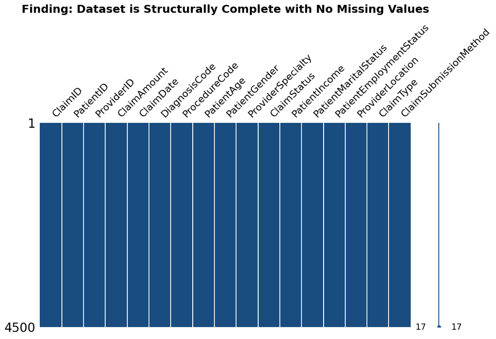

```
Consultant's Note: The matrix confirms that there are no null values in the dataset.
This is a positive finding, allowing us to proceed directly to deeper logical and semantic validation.
```

```python
# Visualize missing values to confirm data completeness
ax = msno.matrix(df, figsize=(12, 6), color=(0.1, 0.3, 0.5))
ax.set_title('Finding: Dataset is Structurally Complete with No Missing Values', fontsize=18, weight='bold')
plt.show()

# Consultant's Note
print("Consultant's Note: The matrix confirms that there are no null values in the dataset.")
print("This is a positive finding, allowing us to proceed directly to deeper logical and semantic validation.")
```